```python
from google.colab import drive
drive.mount("/content/gdrive/")
%cd /content/gdrive/MyDrive/data_science/mile_stone1/
!ls
```

```
/content/gdrive/MyDrive/data_science/mile_stone1
milestone1_final.html  milestone1_final.ipynb  mile_stone1.ipynb
```

# Stocks operating recommendation strategies project

### By Tianyi Xu(https://xutianyi01.github.io/)

Performing an analysis on the historical and earnings data of over 50 tech companies, visualizing trends, and patterns. The goal is to find the most crucial features to do best operating recommendation strategies.

### The Data We're Using and Questions

I find three datasets realted to this project. One dataset is Stock History about stock prices and volumes, two are about Earning Report: one is from Macrotrends(https://www.macrotrends.net/) and the other is from Yahoo Finance(https://finance.yahoo.com/).

#### Stock History

I got my hands on the historical data of these companies as TABLE1, including their stock prices and volumes over the years, using a library called `yfinance`(https://pypi.org/project/yfinance/). TABLE1 is the main dataset we need to focus on, it will describe how the stock price move.

#### Earnings Reports

We’re also looking at earnings data from Macrotrends(TABLE2) and Yahoo Finance(TABLE3) to get an idea of how these companies are doing money-wise, and if they're growing or not. From Macrotrends, I’ve got:

- **Date**: When the earnings report was released.
- **Revenue (in millions)**: Tells us how much money the company raked in.

and we will think about the **question**: Is Revenue the most important feature to decide the how the stock moves? What is the relationship between this feature and other features?

From Yahoo Finance, I’ve got the earnings calendar that includes:

- **Earnings Date**: the date when the earnings were announced.
- **EPS Estimate**: The predicted Earnings Per Share (EPS) - basically, how much profit the company is expected to make for each share.
- **Reported EPS(EPS Actual)**: The actual EPS.

and we will think about the **question**: Is Reported EPS the most important feature to decide the how the stock moves? Compared with other features, Is this a better determinant of stock movement?

#### Trend Indicators

I’m adding in some trend indicators like MACD, RSI, and Bollinger Bands to help us spot patterns and trends in the data more easily by using `pandas_ta`(https://github.com/twopirllc/pandas-ta) library. We tidy TABLE1 and can get these indicators, and we will consider **questions**: Which one of MACD, RSI, Bollinger Bands is the important feature to help us decide the the how to operate stocks strategies? What is the relationship between one feature and other features?

### How we’re working together

Currently, only me do the project. Since no others to work together, I plan to use Google Drive and Google Colab as my development platform.

### Project Plan

Milestone1: 1. get three datasets used for future 2.Tidy each table 3. do three EDAs for three tables

Milestone2: 1. consturct reinforcement learning model, for example, Contextual Bandits or Deep Reinforcement Learning as the model to do operating recommendation strategies. 2. do more EDAs for useful features extraction.

Final: 1. test different features 2. compare the final results and conclusion

### Import all the Necessary Libraries

We use yfinance(https://pypi.org/project/yfinance/) to get the stock daily prices data and use pandas_ta(https://github.com/twopirllc/pandas-ta) to get indicators to be used for future analysis

```python
!pip install pandas_ta
!pip install python-dateutil
import yfinance as yf
import pandas as pd
import matplotlib.pyplot as plt
import requests
from bs4 import BeautifulSoup
import pandas_ta as ta
from dateutil import parser
import time
import seaborn as sns
import warnings
warnings.filterwarnings('ignore')
```

### TABLE1: Get the original dataset from Yahoo Finance for one stock APPLE

Columns Open, High, Low, Close, Adj Close are about stock price. The volume is the number of shares that were traded during a given day.

```python
# Load data from Yahoo Finance
ticker = "AAPL"
stock_data = yf.download(ticker, start="2020-01-01", end="2023-01-01")

# Display the data
display(stock_data.head())

print(stock_data.shape)
display(stock_data.dtypes)
```

```
[*********************100%%**********************]  1 of 1 completed
```

| Date | Open | High | Low | Close | Adj Close | Volume |
| --- | --- | --- | --- | --- | --- | --- |
| 2020-01-02 | 74.059998 | 75.150002 | 73.797501 | 75.087502 | 73.249023 | 135480400 |
| 2020-01-03 | 74.287498 | 75.144997 | 74.125000 | 74.357498 | 72.536896 | 146322800 |
| 2020-01-06 | 73.447502 | 74.989998 | 73.187500 | 74.949997 | 73.114891 | 118387200 |
| 2020-01-07 | 74.959999 | 75.224998 | 74.370003 | 74.597504 | 72.771019 | 108872000 |
| 2020-01-08 | 74.290001 | 76.110001 | 74.290001 | 75.797501 | 73.941650 | 132079200 |

```
(756, 6)
```

```
Open         float64
High         float64
Low          float64
Close        float64
Adj Close    float64
Volume         int64
dtype: object
```

Above dataset is the example of one stock, now we extend it to 50 stocks

### Specifying the Stock Tickers

We have chosen 50 tech company tickers for our analysis.

```python
tickers = [
    "AAPL", "MSFT", "AMZN", "GOOGL", "META", "TSLA", "NVDA", "PYPL", "INTC", "CSCO",
    "ADBE", "CRM", "ACN", "TXN", "ORCL", "QCOM", "IBM", "AVGO", "AMD", "SAP",
    "SHOP", "NOW", "SQ", "INTU", "FIS", "VMW", "HPE", "HPQ", "MU", "AMAT",
    "LRCX", "KLAC", "ADI", "MCHP", "CDNS", "ANSS", "KEYS", "TEL", "WDAY", "CTSH",
    "DOCU", "SNPS", "FTNT", "GLW", "VRSN", "AKAM", "SWKS", "TTD", "EPAM", "NET"
]
```

### TABLE1 Tidy: Add New Indicators

MACD (Moving Average Convergence Divergence): MACD is a trend-following momentum **indicator** that shows the relationship between two moving averages of a stock’s price.

MACD Signal: The MACD signal line is a 9-day EMA of the MACD. When the MACD crosses above the signal line, it gives a bullish (buy) signal, and when it crosses below, it gives a bearish (sell) signal.

MACD Histogram: The MACD histogram is the difference between the MACD and its signal line. A positive histogram suggests that bulls are in control (buying pressure), while a negative histogram suggests bears have control (selling pressure).

RSI (Relative Strength Index): RSI measures the magnitude of recent price changes to evaluate overbought or oversold conditions in the price of a stock. Readings above 70 indicate that a stock may be overbought, and readings below 30 indicate that the stock may be oversold.

Bollinger Upper Band: The upper Bollinger Band is two standard deviations above the simple moving average (SMA) of a stock's price. It helps identify when a stock’s price is considered "high."

Bollinger Middle Band: The middle Bollinger Band is the SMA of the stock’s price, often serving as support or resistance levels for the stock price.

Bollinger Lower Band: The lower Bollinger Band is two standard deviations below the SMA of the stock’s price. It helps identify when a stock’s price is considered "low."

```python
def fetch_and_enhance_stock_data(tickers):
    all_data = []

    for ticker in tickers:
        try:
            # Fetch historical stock data
            stock_data = yf.download(ticker, start="2010-01-01", end="2023-01-01")

            # Calculate MACD
            macd = ta.macd(stock_data['Close'])
            stock_data['MACD'] = macd.iloc[:, 0]
            stock_data['MACD Signal'] = macd.iloc[:, 1]
            stock_data['MACD Histogram'] = macd.iloc[:, 2]

            # Calculate RSI
            stock_data['RSI'] = ta.rsi(stock_data['Close'])

            # Calculate Bollinger Bands
            bbands = ta.bbands(stock_data['Close'])
            stock_data['Bollinger Lower'] = bbands.iloc[:, 0]
            stock_data['Bollinger Middle'] = bbands.iloc[:, 1]
            stock_data['Bollinger Upper'] = bbands.iloc[:, 2]

            stock_data['Stock'] = ticker
            cols = ['Stock'] + [col for col in stock_data if col != 'Stock']
            stock_data = stock_data[cols]
            # Drop nan
            all_data.append(stock_data.dropna())
        except Exception as e:
            print(f"Could not retrieve data for {ticker}: {str(e)}")
            continue

    # Concatenate all the individual DataFrames into one
    combined_data = pd.concat(all_data, axis=0)

    return combined_data


# Fetch and enhance the stock data
stock_data = fetch_and_enhance_stock_data(tickers)

display(stock_data.head(10))
print(stock_data.shape)
display(stock_data.dtypes)
```

[output not shown]

| Date | Stock | Open | High | Low | Close | Adj Close | Volume | MACD | MACD Signal | MACD Histogram | RSI | Bollinger Lower | Bollinger Middle | Bollinger Upper |
| --- | --- | --- | --- | --- | --- | --- | --- | --- | --- | --- | --- | --- | --- | --- |
| 2010-02-22 | AAPL | 7.226429 | 7.232143 | 7.113929 | 7.157857 | 6.075564 | 390563600 | -0.088343 | 0.066146 | -0.154489 | 47.617442 | 7.145997 | 7.221214 | 7.296432 |
| 2010-02-23 | AAPL | 7.142857 | 7.190357 | 6.989643 | 7.037857 | 5.973709 | 575094800 | -0.091067 | 0.050738 | -0.141805 | 43.102673 | 7.024712 | 7.175929 | 7.327145 |
| 2010-02-24 | AAPL | 7.079643 | 7.194286 | 7.065714 | 7.166429 | 6.082839 | 460566400 | -0.081906 | 0.047918 | -0.129825 | 48.713452 | 7.022721 | 7.162429 | 7.302136 |
| 2010-02-25 | AAPL | 7.049286 | 7.245000 | 7.031786 | 7.214286 | 6.123460 | 665126000 | -0.069979 | 0.047877 | -0.117856 | 50.663657 | 7.030473 | 7.155786 | 7.281099 |
| 2010-02-26 | AAPL | 7.227857 | 7.327500 | 7.214286 | 7.307857 | 6.202884 | 507460800 | -0.052372 | 0.052387 | -0.104759 | 54.321085 | 7.001694 | 7.176857 | 7.352020 |
| 2010-03-01 | AAPL | 7.348214 | 7.482143 | 7.337500 | 7.463929 | 6.335358 | 550093600 | -0.025530 | 0.063383 | -0.088913 | 59.688942 | 6.952883 | 7.238072 | 7.523261 |
| 2010-03-02 | AAPL | 7.497500 | 7.529643 | 7.419286 | 7.458929 | 6.331114 | 566546400 | -0.004608 | 0.067444 | -0.072052 | 59.447917 | 7.077504 | 7.322286 | 7.567068 |
| 2010-03-03 | AAPL | 7.462143 | 7.495357 | 7.426429 | 7.476071 | 6.345663 | 372052800 | 0.013204 | 0.068205 | -0.055001 | 60.043600 | 7.174299 | 7.384214 | 7.594130 |
| 2010-03-04 | AAPL | 7.474286 | 7.532857 | 7.451071 | 7.525357 | 6.387496 | 366041200 | 0.030940 | 0.068753 | -0.037813 | 61.781887 | 7.300079 | 7.446429 | 7.592779 |
| 2010-03-05 | AAPL | 7.676429 | 7.846429 | 7.665357 | 7.819643 | 6.637287 | 899620400 | 0.067959 | 0.084617 | -0.016658 | 70.136225 | 7.273868 | 7.548786 | 7.823704 |

```
(146264, 14)
```

```
Stock                object
Open                float64
High                float64
Low                 float64
Close               float64
Adj Close           float64
Volume                int64
MACD                float64
MACD Signal         float64
MACD Histogram      float64
RSI                 float64
Bollinger Lower     float64
Bollinger Middle    float64
Bollinger Upper     float64
dtype: object
```

### TABLE2: Function to Fetch Earnings Data from Macrotrends

A function to scrape earnings data from Macrotrends(https://www.macrotrends.net/) for each stock. We can use Apple Quarterly Revenue as a long-term investment decision.

```python
headers = {'User-Agent': 'Mozilla/5.0 (Windows NT 10.0; Win64; x64) AppleWebKit/537.36 (KHTML, like Gecko) Chrome/91.0.4472.124 Safari/537.36'}

def fetch_macrotrends_earnings_data(ticker):
    url = f'https://www.macrotrends.net/stocks/charts/{ticker.lower()}/{ticker}/revenue'
    response = requests.get(url, headers=headers)
    if response.status_code != 200:
        print(f"Failed to retrieve the data for {ticker}")
        return None

    soup = BeautifulSoup(response.text, 'html.parser')
    table = soup.find_all('table')[1]
    earnings_data = pd.read_html(str(table))[0]

    return earnings_data

apple_earnings_data = fetch_macrotrends_earnings_data('AAPL')
display(apple_earnings_data.head(10))
print(apple_earnings_data.shape)
display(apple_earnings_data.dtypes)
```

|  | Apple Quarterly Revenue (Millions of US $) | Apple Quarterly Revenue (Millions of US $).1 |
| --- | --- | --- |
| 0 | 2023-06-30 | $81,797 |
| 1 | 2023-03-31 | $94,836 |
| 2 | 2022-12-31 | $117,154 |
| 3 | 2022-09-30 | $90,146 |
| 4 | 2022-06-30 | $82,959 |
| 5 | 2022-03-31 | $97,278 |
| 6 | 2021-12-31 | $123,945 |
| 7 | 2021-09-30 | $83,360 |
| 8 | 2021-06-30 | $81,434 |
| 9 | 2021-03-31 | $89,584 |

```
(58, 2)
```

```
Apple Quarterly Revenue (Millions of US $)      object
Apple Quarterly Revenue (Millions of US $).1    object
dtype: object
```

### TABLE2 Tidy: Clean data and combine all 50 stocks

```python
def clean_macrotrends_earnings_data(df, ticker):
    df.columns = ['Date', 'Revenue']
    df['Date'] = pd.to_datetime(df['Date'])
    df['Revenue'] = df['Revenue'].str.replace('$', '').str.replace(',', '').astype(float)
    df['Stock'] = ticker
    return df

# Fetch and clean earnings data for all stocks
all_earnings_data = []

for ticker in tickers:
    raw_earnings_data = fetch_macrotrends_earnings_data(ticker)
    if raw_earnings_data is not None:
        cleaned_earnings_data = clean_macrotrends_earnings_data(raw_earnings_data, ticker)
        all_earnings_data.append(cleaned_earnings_data)

# Combine all earnings data into a single DataFrame
combined_earnings_data = pd.concat(all_earnings_data, axis=0)
```

```python
display(combined_earnings_data.head(10))
print(combined_earnings_data.shape)
display(combined_earnings_data.dtypes)
```

|  | Date | Revenue | Stock |
| --- | --- | --- | --- |
| 0 | 2023-06-30 | 81797.0 | AAPL |
| 1 | 2023-03-31 | 94836.0 | AAPL |
| 2 | 2022-12-31 | 117154.0 | AAPL |
| 3 | 2022-09-30 | 90146.0 | AAPL |
| 4 | 2022-06-30 | 82959.0 | AAPL |
| 5 | 2022-03-31 | 97278.0 | AAPL |
| 6 | 2021-12-31 | 123945.0 | AAPL |
| 7 | 2021-09-30 | 83360.0 | AAPL |
| 8 | 2021-06-30 | 81434.0 | AAPL |
| 9 | 2021-03-31 | 89584.0 | AAPL |

```
(2707, 3)
```

```
Date       datetime64[ns]
Revenue           float64
Stock              object
dtype: object
```

### EDA for TABLE2:

We can find that Apple's quarterly revenue is the highest compared with MSFT and GOOGL. And it is increasing year by year, we can infer that Apple's stock price should rise year by year and the increase rate may be higher than MSFT and GOOGL.

```
             Revenue
count    2679.000000
mean     7341.410228
std     14817.978635
min    -26397.000000
25%       705.000000
50%      2230.000000
75%      7286.500000
max    149204.000000
```

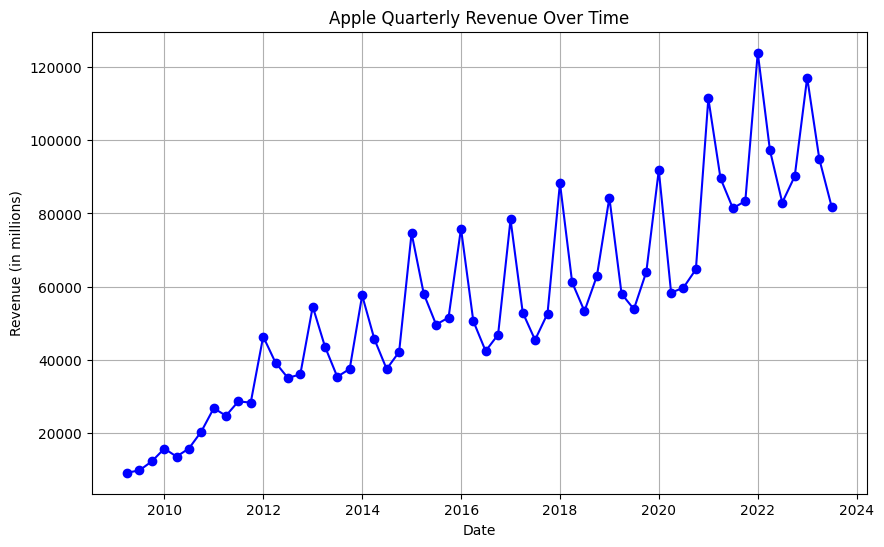

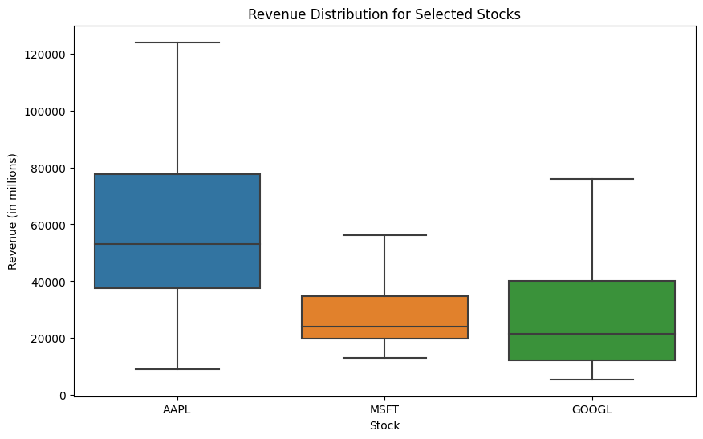

```python
# Display basic statistics
print(combined_earnings_data.describe())

# Plotting the revenue over time for Apple
plt.figure(figsize=(10, 6))
apple_data = combined_earnings_data[combined_earnings_data['Stock'] == 'AAPL']
plt.plot(apple_data['Date'], apple_data['Revenue'], marker='o', linestyle='-', color='b')
plt.title('Apple Quarterly Revenue Over Time')
plt.xlabel('Date')
plt.ylabel('Revenue (in millions)')
plt.grid(True)
plt.show()

# Plotting the revenue distributions for Apple, Microsoft, and Google
selected_stocks = ['AAPL', 'MSFT', 'GOOGL']
selected_data = combined_earnings_data[combined_earnings_data['Stock'].isin(selected_stocks)]

plt.figure(figsize=(10, 6))
sns.boxplot(x='Stock', y='Revenue', data=selected_data)
plt.title('Revenue Distribution for Selected Stocks')
plt.xlabel('Stock')
plt.ylabel('Revenue (in millions)')
plt.show()
```

### TABLE3: Fetching Earnings Data from Yahoo Finance

A function to scrape earnings data from Yahoo Finance(https://finance.yahoo.com/) for each stock. We can use Reported EPS as a long-term investment decision.

```python
def fetch_yahoo_earnings_data(ticker):
    url = f'https://finance.yahoo.com/calendar/earnings?symbol={ticker}'
    response = requests.get(url, headers=headers)

    if response.status_code != 200:
        print(f"Failed to retrieve the data for {ticker}")
        return None

    soup = BeautifulSoup(response.text, 'html.parser')
    table = soup.find('table')
    earnings_data = pd.read_html(str(table))[0]

    return earnings_data

msft_yahoo_earnings_data = fetch_yahoo_earnings_data('MSFT')
display(msft_yahoo_earnings_data.head(10))
print(msft_yahoo_earnings_data.shape)
display(msft_yahoo_earnings_data.dtypes)
```

|  | Symbol | Company | Earnings Date | EPS Estimate | Reported EPS | Surprise(%) |
| --- | --- | --- | --- | --- | --- | --- |
| 0 | MSFT | Microsoft Corp | Jul 23, 2024, 6 AMEDT | - | - | - |
| 1 | MSFT | Microsoft Corp | Apr 23, 2024, 6 AMEDT | - | - | - |
| 2 | MSFT | Microsoft Corp | Jan 22, 2024, 4 PMEST | - | - | - |
| 3 | MSFT | Microsoft Corp | Jan 22, 2024, 5 AMEST | - | - | - |
| 4 | MSFT | Microsoft Corp | Oct 23, 2023, 6 AMEDT | 2.65 | - | - |
| 5 | MSFT | Microsoft Corporation | Jul 25, 2023, 12 PMEDT | 2.55 | 2.69 | +5.49 |
| 6 | MSFT | Microsoft Corporation | Apr 25, 2023, 12 PMEDT | 2.23 | 2.45 | +9.81 |
| 7 | MSFT | Microsoft Corporation | Jan 24, 2023, 11 AMEST | 2.29 | 2.32 | +1.09 |
| 8 | MSFT | Microsoft Corporation | Oct 25, 2022, 12 PMEDT | 2.3 | 2.35 | +2.05 |
| 9 | MSFT | Microsoft Corporation | Jul 26, 2022, 12 PMEDT | 2.29 | 2.23 | -2.74 |

```
(100, 6)
```

```
Symbol           object
Company          object
Earnings Date    object
EPS Estimate     object
Reported EPS     object
Surprise(%)      object
dtype: object
```

### TABLE3 Tidy: Clean above table

```python
def parse_date(date_string):
    try:
        return parser.parse(date_string)
    except Exception as e:
        return None



def clean_yahoo_earnings_data(df, ticker):
    cleaned_data = []
    for index, row in df.iterrows():
        try:
            if row['EPS Estimate'] == '-' or row['Reported EPS'] == '-' or row['Surprise(%)'] == '-':
                continue

            date_string = row['Earnings Date']

            earnings_date = parse_date(date_string)
            eps_estimate = float(row['EPS Estimate']) if row['EPS Estimate'] != '-' else None
            reported_eps = float(row['Reported EPS']) if row['Reported EPS'] != '-' else None
            surprise = float(row['Surprise(%)'].replace('%', '')) if row['Surprise(%)'] != '-' else None

            cleaned_data.append([ticker, earnings_date, eps_estimate, reported_eps, surprise])
        except Exception as e:
            continue


    cleaned_df = pd.DataFrame(cleaned_data, columns=['Stock', 'Earnings Date', 'EPS Estimate', 'Reported EPS', 'Surprise(%)'])
    return cleaned_df
```

### TABLE3 Tidy: Combine all 50 stocks

```python
all_yahoo_earnings_data = []

for ticker in tickers:
    raw_yahoo_earnings_data = fetch_yahoo_earnings_data(ticker)

    if raw_yahoo_earnings_data is not None and not raw_yahoo_earnings_data.empty:
        cleaned_yahoo_earnings_data = clean_yahoo_earnings_data(raw_yahoo_earnings_data, ticker)

        if not cleaned_yahoo_earnings_data.empty:
            all_yahoo_earnings_data.append(cleaned_yahoo_earnings_data)
        time.sleep(1)

if all_yahoo_earnings_data:
    combined_yahoo_earnings_data = pd.concat(all_yahoo_earnings_data, ignore_index=True)
else:
    print("No data to display.")
```

```python
display(combined_yahoo_earnings_data.head(10))
print(combined_yahoo_earnings_data.shape)
display(combined_yahoo_earnings_data.dtypes)
```

|  | Stock | Earnings Date | EPS Estimate | Reported EPS | Surprise(%) |
| --- | --- | --- | --- | --- | --- |
| 0 | AAPL | 2023-08-03 12:00:00 | 1.19 | 1.26 | 5.49 |
| 1 | AAPL | 2023-05-04 12:00:00 | 1.43 | 1.52 | 6.03 |
| 2 | AAPL | 2023-02-02 11:00:00 | 1.94 | 1.88 | -2.88 |
| 3 | AAPL | 2022-10-27 12:00:00 | 1.27 | 1.29 | 1.55 |
| 4 | AAPL | 2022-07-28 12:00:00 | 1.16 | 1.20 | 3.25 |
| 5 | AAPL | 2022-04-28 12:00:00 | 1.43 | 1.52 | 6.44 |
| 6 | AAPL | 2022-01-27 11:00:00 | 1.89 | 2.10 | 11.17 |
| 7 | AAPL | 2021-10-28 12:00:00 | 1.24 | 1.24 | 0.30 |
| 8 | AAPL | 2021-07-27 12:00:00 | 1.01 | 1.30 | 29.12 |
| 9 | AAPL | 2021-04-28 12:00:00 | 0.99 | 1.40 | 41.89 |

```
(3414, 5)
```

```
Stock                    object
Earnings Date    datetime64[ns]
EPS Estimate            float64
Reported EPS            float64
Surprise(%)             float64
dtype: object
```

### EDA for TABLE3:

We can find that Reported EPS is increasing over years, so we can infer that Apple's stock price should rise year by year. One interesting thing is that despite Apple's quarterly revenue is the higher compared with MSFT and GOOGL, but Apple's Reported EPS is lower than MSFT. So we want to plot the real stock movements in the final part to compare Apple and Microsoft.

```
       EPS Estimate  Reported EPS  Surprise(%)
count   3414.000000   3414.000000  3414.000000
mean       0.724971      0.774725    14.159482
std        1.064862      1.111889    76.297482
min       -1.580000     -1.910000 -1616.790000
25%        0.140000      0.170000     1.915000
50%        0.420000      0.450000     6.065000
75%        0.910000      0.987500    13.767500
max       10.420000     10.710000  1283.470000
Stock              0
Earnings Date    260
EPS Estimate       0
Reported EPS       0
Surprise(%)        0
dtype: int64
```

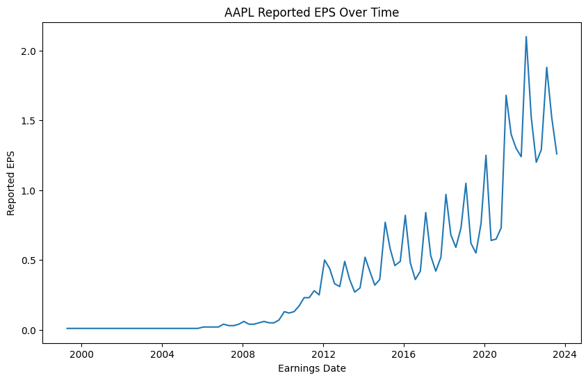

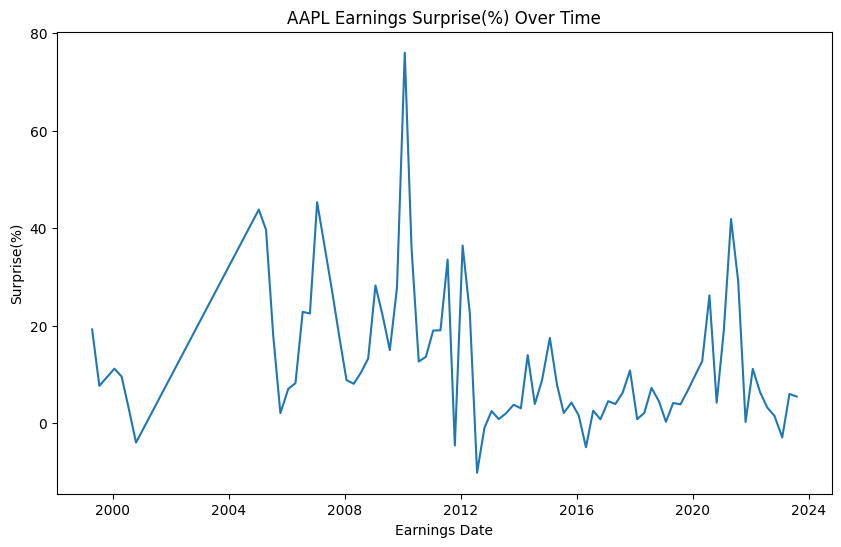

```python
print(combined_yahoo_earnings_data.describe())
print(combined_yahoo_earnings_data.isnull().sum())
combined_yahoo_earnings_data.dropna(inplace=True)

# After fetching and cleaning the data, filter it to include only AAPL’s data
aapl_earnings_data = combined_yahoo_earnings_data[combined_yahoo_earnings_data['Stock'] == 'AAPL']

# plotting Reported EPS over time
plt.figure(figsize=(10, 6))
sns.lineplot(data=aapl_earnings_data, x='Earnings Date', y='Reported EPS')
plt.title('AAPL Reported EPS Over Time')
plt.show()

# plotting the Surprise(%) over time
plt.figure(figsize=(10, 6))
sns.lineplot(data=aapl_earnings_data, x='Earnings Date', y='Surprise(%)')
plt.title('AAPL Earnings Surprise(%) Over Time')
plt.show()
```

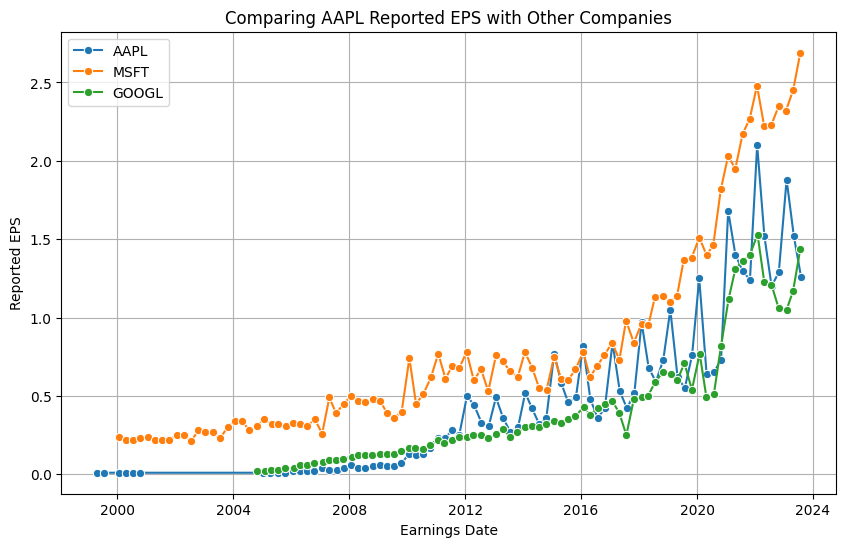

```python
# Compare AAPL's Reported EPS with other companies
others_earnings_data = combined_yahoo_earnings_data[combined_yahoo_earnings_data['Stock'] == 'MSFT']
google_earnings_data = combined_yahoo_earnings_data[combined_yahoo_earnings_data['Stock'] == 'GOOGL']

plt.figure(figsize=(10, 6))
sns.lineplot(data=aapl_earnings_data, x='Earnings Date', y='Reported EPS', marker="o", label='AAPL')
sns.lineplot(data=others_earnings_data, x='Earnings Date', y='Reported EPS', marker="o", label='MSFT')
sns.lineplot(data=google_earnings_data, x='Earnings Date', y='Reported EPS', marker="o", label='GOOGL')
plt.title('Comparing AAPL Reported EPS with Other Companies')
plt.grid(True)
plt.show()
```

### EDA for TABLE1:

```
[*********************100%%**********************]  1 of 1 completed
[*********************100%%**********************]  1 of 1 completed
```

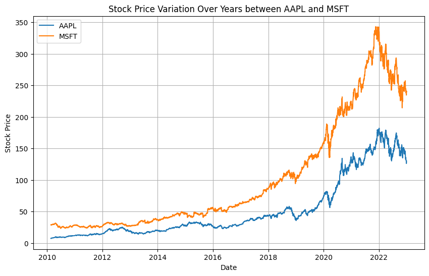

```python
# Extract stock data with AAPL and MSFT
stock_data = fetch_and_enhance_stock_data(['AAPL', 'MSFT'])
aapl_data = stock_data[stock_data['Stock'] == 'AAPL']
msft_data = stock_data[stock_data['Stock'] == 'MSFT']

# Plotting the data
plt.figure(figsize=(10,6))
sns.lineplot(data=aapl_data, x=aapl_data.index, y='Close', label='AAPL')
sns.lineplot(data=msft_data, x=msft_data.index, y='Close', label='MSFT')

plt.title('Stock Price Variation Over Years between AAPL and MSFT')
plt.ylabel('Stock Price')
plt.xlabel('Date')
plt.grid(True)
plt.legend()
plt.show()
```

# Conclusion

We summarize our findings, insights, and observations from the data analysis and visualizations. This can be expanded upon further analysis and interpretation. We can focus on Reported EPS and in the future we will consider more features and use our reinforcement learning model to compare the results between different features.

```python
!pip install --upgrade nbconvert
```

```python
%%shell
jupyter nbconvert --to html /content/gdrive/MyDrive/data_science/mile_stone1/milestone1_final.ipynb
```

```
[NbConvertApp] Converting notebook /content/gdrive/MyDrive/data_science/mile_stone1/milestone1_final.ipynb to html
[NbConvertApp] Writing 800378 bytes to /content/gdrive/MyDrive/data_science/mile_stone1/milestone1_final.html
```